# What Is Shared Across CLL Omics Layers?

## Molecular signatures

```r
top25_tbl <- rank_features(
  ajive_output = cll_fit,
  mode         = "top_loadings",
  type         = "joint",
  block        = 1L,
  component    = 1L,
  n            = 25L,
  signed       = TRUE
)
knitr::kable(head(top25_tbl, 10), digits = 4,
             caption = "Top-ranked mRNA loadings from rank_features()")
```

Top-ranked mRNA loadings from rank_features()

| block | component | type | feature_index | feature_name | loading | abs_loading | rank |
| --- | --- | --- | --- | --- | --- | --- | --- |
| 1 | 1 | joint | 165 | NA | -0.1143 | 0.1143 | 1 |
| 1 | 1 | joint | 26 | NA | -0.1077 | 0.1077 | 2 |
| 1 | 1 | joint | 31 | NA | -0.1070 | 0.1070 | 3 |
| 1 | 1 | joint | 20 | NA | -0.1066 | 0.1066 | 4 |
| 1 | 1 | joint | 37 | NA | -0.1052 | 0.1052 | 5 |
| 1 | 1 | joint | 25 | NA | -0.1050 | 0.1050 | 6 |
| 1 | 1 | joint | 417 | NA | -0.1049 | 0.1049 | 7 |
| 1 | 1 | joint | 23 | NA | -0.1046 | 0.1046 | 8 |
| 1 | 1 | joint | 280 | NA | -0.0987 | 0.0987 | 9 |
| 1 | 1 | joint | 95 | NA | -0.0966 | 0.0966 | 10 |

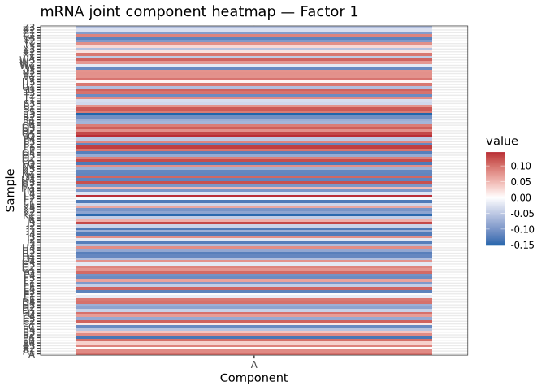

```r
plot_components(cll_fit,
                plot_type = "component_heatmap",
                type      = "joint",
                block     = 1L,
                component = 1L) +
  labs(title = "mRNA joint component heatmap — Factor 1")
```

## Can factors predict clinical labels?

### IGHV status (Random Forest)

We train a random forest on the joint factor scores to predict IGHV status. Samples missing IGHV labels can then be imputed, echoing the prediction step in the MOFA2 CLL vignette.

```r
if (requireNamespace("randomForest", quietly = TRUE)) {
  rf_df <- data.frame(
    joint_sc_m,
    IGHV = factor(meta_m$IGHV[match(rownames(joint_sc_m), rownames(meta_m))])
  )
  rf_df_train <- rf_df[!is.na(rf_df$IGHV), , drop = FALSE]
  set.seed(42)
  rf_fit <- randomForest::randomForest(IGHV ~ ., data = rf_df_train, ntree = 500L)
  cat("OOB error (IGHV prediction):",
      round(rf_fit$err.rate[nrow(rf_fit$err.rate), "OOB"] * 100, 1), "%\n")
  print(rf_fit$confusion)

  # Impute all samples (including those with missing labels)
  rf_df$IGHV_pred   <- stats::predict(rf_fit, rf_df)
  rf_df$IGHV_source <- ifelse(
    is.na(meta_m$IGHV[match(rownames(rf_df), rownames(meta_m))]),
    "Predicted", "Observed"
  )
}
```

```
#> OOB error (IGHV prediction): 8 %
#>    M  U class.error
#> M 54  3  0.05263158
#> U  6 49  0.10909091
```

The plot places observed and imputed IGHV labels back into Factor 1 versus Factor 3 space, making the imputation visually auditable.

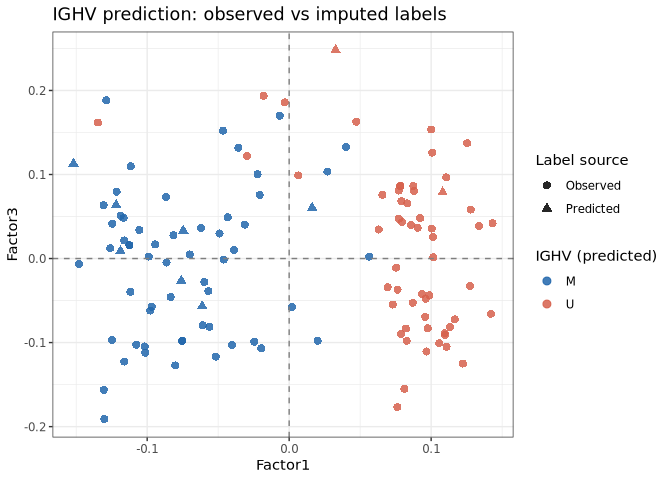

```r
if (exists("rf_df") && ncol(joint_sc_m) >= 3) {
  pred_df <- data.frame(
    Factor1     = joint_sc_m[rownames(rf_df), "Factor1"],
    Factor3     = joint_sc_m[rownames(rf_df), "Factor3"],
    IGHV_pred   = rf_df$IGHV_pred,
    IGHV_source = rf_df$IGHV_source
  )
  ggplot(pred_df,
         aes(x = Factor1, y = Factor3,
             colour = IGHV_pred, shape = IGHV_source)) +
    geom_point(size = 2.5, alpha = 0.85) +
    scale_colour_manual(values = c("M" = "#2166ac", "U" = "#d6604d")) +
    scale_shape_manual(values  = c("Observed" = 16, "Predicted" = 17)) +
    geom_hline(yintercept = 0, linetype = "dashed", colour = "grey50") +
    geom_vline(xintercept = 0, linetype = "dashed", colour = "grey50") +
    labs(title  = "IGHV prediction: observed vs imputed labels",
         colour = "IGHV (predicted)",
         shape  = "Label source") +
    theme_bw()
}
```

## Survival Analysis

### Data preparation

```r
if (requireNamespace("survival", quietly = TRUE)) {
  # T5 = time to first treatment (years); treatedAfter = event indicator
  surv_df <- data.frame(
    joint_sc_m,
    TTT          = meta_m$T5[match(rownames(joint_sc_m), rownames(meta_m))],
    treatedAfter = as.integer(
      meta_m$treatedAfter[match(rownames(joint_sc_m), rownames(meta_m))]
    )
  )
  surv_df <- surv_df[!is.na(surv_df$TTT) & !is.na(surv_df$treatedAfter), ,
                     drop = FALSE]
  cat("Samples with survival data:", nrow(surv_df), "\n")
}
```

```
#> Samples with survival data: 115
```

### Cox proportional-hazards model

```r
if (requireNamespace("survival", quietly = TRUE) &&
    exists("surv_df") && nrow(surv_df) > 10) {
  factor_cols <- paste(paste0("Factor", seq_len(get_joint_rank(cll_fit))),
                       collapse = " + ")
  cox_fit <- survival::coxph(
    as.formula(paste("survival::Surv(TTT, treatedAfter) ~", factor_cols)),
    data = surv_df
  )
  knitr::kable(round(summary(cox_fit)$coefficients, 4),
               caption = "Cox PH: joint factors vs time to treatment")
}
```

Cox PH: joint factors vs time to treatment

|  | coef | exp(coef) | se(coef) | z | Pr(>\|z\|) |
| --- | --- | --- | --- | --- | --- |
| Factor1 | 8.5979 | 5420.0785 | 1.6109 | 5.3375 | 0.0000 |
| Factor2 | -2.2781 | 0.1025 | 1.4229 | -1.6011 | 0.1094 |
| Factor3 | 5.1329 | 169.5033 | 1.2825 | 4.0024 | 0.0001 |
| Factor4 | 0.6048 | 1.8310 | 1.5177 | 0.3985 | 0.6902 |
| Factor5 | 4.3969 | 81.2016 | 1.4444 | 3.0441 | 0.0023 |

### Hazard ratio forest plot

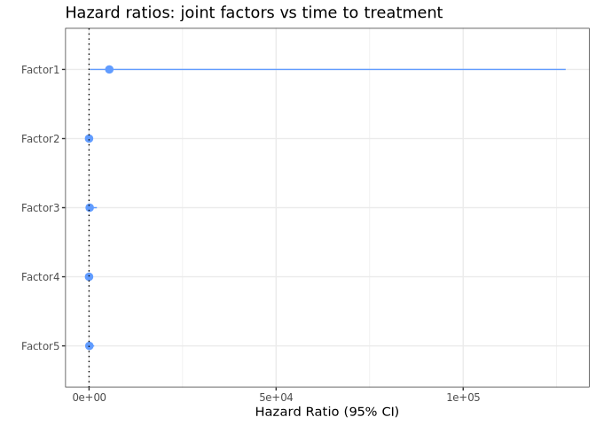

```r
if (requireNamespace("survival", quietly = TRUE) && exists("cox_fit")) {
  s     <- summary(cox_fit)
  coefs <- s[["coefficients"]]
  ci    <- s[["conf.int"]]

  hr_df <- data.frame(
    factor = factor(rownames(coefs), levels = rev(rownames(coefs))),
    p      = coefs[, "Pr(>|z|)"],
    HR     = ci[, "exp(coef)"],
    lower  = ci[, "lower .95"],
    upper  = ci[, "upper .95"]
  )

  ggplot(hr_df, aes(x = factor, y = HR, ymin = lower, ymax = upper)) +
    geom_pointrange(colour = "#619CFF") +
    geom_hline(aes(yintercept = 1), linetype = "dotted") +
    coord_flip() +
    labs(title = "Hazard ratios: joint factors vs time to treatment",
         x = "", y = "Hazard Ratio (95% CI)") +
    theme_bw()
}
```

### Kaplan-Meier curve (optimal cutpoint)

```r
if (requireNamespace("survminer", quietly = TRUE) &&
    requireNamespace("survival",  quietly = TRUE) &&
    exists("surv_df") && nrow(surv_df) > 10) {

  # Optimal cutpoint via maximally selected rank statistic
  cut_res <- survminer::surv_cutpoint(
    data      = surv_df,
    time      = "TTT",
    event     = "treatedAfter",
    variables = "Factor1"
  )
  opt_cut <- cut_res$cutpoint$cutpoint
  surv_df$Factor1_group <- ifelse(surv_df$Factor1 > opt_cut, "High", "Low")

  km_fit <- survival::survfit(
    survival::Surv(TTT, treatedAfter) ~ Factor1_group, data = surv_df
  )
  survminer::ggsurvplot(
    km_fit, data = surv_df,
    pval        = TRUE,
    conf.int    = TRUE,
    risk.table  = TRUE,
    palette     = c("#d6604d", "#2166ac"),
    title       = sprintf("Time to treatment by Factor 1 (cutpoint = %.2f)", opt_cut),
    xlab        = "Time (years)",
    ylab        = "Survival probability (%)",
    fun         = function(y) y * 100,
    legend.labs = c("High Factor 1", "Low Factor 1")
  )
}
```

[output not shown]

## How does this compare with MOFA2?

The MOFA2 CLL analysis (Argelaguet et al. 2020) reported four latent factors. The table below maps the main biological interpretations across methods. Factor numbers are not directly comparable: MOFA2 orders factors by total variance explained, whereas RaJIVE factors reflect the geometry of the joint subspace.

```r
jrank   <- get_joint_rank(cll_fit)
signals <- c(
  "IGHV status / B-cell differentiation (cf. MOFA2 Factor 1)",
  "Trisomy 12 / proliferative signalling (cf. MOFA2 Factor 3)",
  rep("Inspect loadings — no MOFA2 analogue identified", max(0L, jrank - 2L))
)[seq_len(jrank)]
evidence <- c(
  "High |r| with IGHV; separates M/U in score plots",
  "Inspect mRNA + drug loadings; check trisomy12 association",
  rep("See loading heatmap", max(0L, jrank - 2L))
)[seq_len(jrank)]

comp_df <- data.frame(
  `RaJIVE Factor`     = paste0("Factor ", seq_len(jrank)),
  `Biological signal` = signals,
  `Key evidence`      = evidence,
  check.names = FALSE
)
knitr::kable(comp_df,
             caption = "RaJIVE-MOFA2 factor correspondence (preliminary)")
```

RaJIVE-MOFA2 factor correspondence (preliminary)

[output not shown]

> **Methodological note.** MOFA2 is a probabilistic latent factor model with view-specific likelihoods; RaJIVE is a deterministic matrix decomposition that maximizes explained variance under a Gaussian assumption. Both methods identify IGHV status as a dominant CLL axis. The differences matter: RaJIVE gives a hard joint/individual split, its jackstraw test gives feature-level significance without a sparse prior, and MOFA2 natively handles non-Gaussian views such as binary mutations and counts.